# Zillow's Home Value Prediction Models

Shijie Zhao RUID 197002077

# Import Data

```python
#library dependencies
import numpy as np
import pandas as pd
import bokeh
import sklearn
import xgboost as xgb
from xgboost import XGBRegressor
from scipy.stats import norm
from numpy import loadtxt
from numpy import sort
import matplotlib.pyplot as plt
import seaborn as sns
import matplotlib.mlab as mlab
import sqlite3
from scipy import stats
from sklearn import neighbors
from sklearn.model_selection import train_test_split
from sklearn.model_selection import GridSearchCV
from sklearn.metrics import classification_report
from sklearn.model_selection import StratifiedKFold
from sklearn.feature_selection import SelectFromModel
from sklearn.model_selection import KFold
from sklearn.model_selection import cross_val_score
from sklearn.metrics import mean_absolute_error
from sklearn.metrics import f1_score
from sklearn.preprocessing import OneHotEncoder
from sklearn.preprocessing import StandardScaler
from sklearn.preprocessing import LabelEncoder

#import properties 2016 data
prop2016=pd.read_csv('/Users/stella/Documents/Capstone/properties_2016.csv')
#import train 2016 data
train2016=pd.read_csv('/Users/stella/Documents/Capstone/train_2016_v2.csv',parse_dates=['transactiondate'])
#merge
df_train=train2016.merge(prop2016, how='left', on='parcelid')
df_train['transaction_month'] = df_train['transactiondate'].dt.month
num_month=df_train['transaction_month'].value_counts()
```

## Step 1 Exploratory data analysis

### Logerror:

- Target variable for this problem is "logerror" field. So let us do some analysis on this field first.
- Some outliers at both the ends

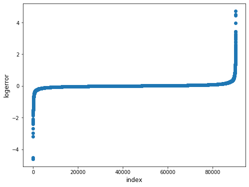

```python
plt.figure(figsize=(8,6))
plt.scatter(range(df_train.shape[0]), np.sort(df_train.logerror.values))
plt.xlabel('index', fontsize=12)
plt.ylabel('logerror', fontsize=12)
plt.show()
```

### Transaction Date:

- Now let us explore the date field. Let us first check the number of transactions in each month.
- As we could see from the data description as well the train data has all the transactions before October 15, 2016, plus some of the transactions after October 15, 2016. So we have shorter bars in the last three months

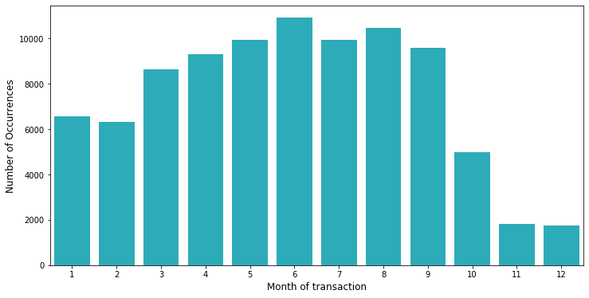

```python
color=sns.color_palette()
plt.figure(figsize=(12,6))
sns.barplot(num_month.index, num_month.values, color=color[9])
plt.xlabel('Month of transaction', fontsize=12)
plt.ylabel('Number of Occurrences', fontsize=12)
plt.show()
```

### Missing Value Analysis:

- There are so many NaN values in properties_2016 dataset. So let us first do some exploration on that one.
- 35% of the attributes are missing more than 90% of values.

```python
#missing values
missing_df = prop2016.isnull().sum(axis=0).reset_index()
missing_df.columns = ['column_name', 'missing_count']
missing_df = missing_df.loc[missing_df['missing_count']>0]
missing_df = missing_df.sort_values(by='missing_count')
missing_df
```

|  | column_name | missing_count |
| --- | --- | --- |
| 35 | rawcensustractandblock | 11437 |
| 25 | longitude | 11437 |
| 24 | latitude | 11437 |
| 37 | regionidcounty | 11437 |
| 17 | fips | 11437 |
| 33 | propertylandusetypeid | 11437 |
| 52 | assessmentyear | 11439 |
| 5 | bedroomcnt | 11450 |
| 4 | bathroomcnt | 11462 |
| 40 | roomcnt | 11475 |
| 32 | propertycountylandusecode | 12277 |
| 39 | regionidzip | 13980 |
| 54 | taxamount | 31250 |
| 51 | taxvaluedollarcnt | 42550 |
| 50 | structuretaxvaluedollarcnt | 54982 |
| 11 | calculatedfinishedsquarefeet | 55565 |
| 47 | yearbuilt | 59928 |
| 36 | regionidcity | 62845 |
| 53 | landtaxvaluedollarcnt | 67733 |
| 57 | censustractandblock | 75126 |
| 19 | fullbathcnt | 128912 |
| 8 | calculatedbathnbr | 128912 |
| 12 | finishedsquarefeet12 | 276033 |
| 26 | lotsizesquarefeet | 276099 |
| 34 | propertyzoningdesc | 1006588 |
| 44 | unitcnt | 1007727 |
| 7 | buildingqualitytypeid | 1046729 |
| 23 | heatingorsystemtypeid | 1178816 |
| 38 | regionidneighborhood | 1828815 |
| 21 | garagetotalsqft | 2101950 |
| 20 | garagecarcnt | 2101950 |
| 1 | airconditioningtypeid | 2173698 |
| 48 | numberofstories | 2303148 |
| 27 | poolcnt | 2467683 |
| 31 | pooltypeid7 | 2499758 |
| 18 | fireplacecnt | 2672580 |
| 42 | threequarterbathnbr | 2673586 |
| 10 | finishedfloor1squarefeet | 2782500 |
| 15 | finishedsquarefeet50 | 2782500 |
| 14 | finishedsquarefeet15 | 2794419 |
| 45 | yardbuildingsqft17 | 2904862 |
| 22 | hashottuborspa | 2916203 |
| 56 | taxdelinquencyyear | 2928753 |
| 55 | taxdelinquencyflag | 2928755 |
| 29 | pooltypeid10 | 2948278 |
| 30 | pooltypeid2 | 2953142 |
| 28 | poolsizesum | 2957257 |
| 16 | finishedsquarefeet6 | 2963216 |
| 9 | decktypeid | 2968121 |
| 6 | buildingclasstypeid | 2972588 |
| 13 | finishedsquarefeet13 | 2977545 |
| 43 | typeconstructiontypeid | 2978470 |
| 2 | architecturalstyletypeid | 2979156 |
| 49 | fireplaceflag | 2980054 |
| 46 | yardbuildingsqft26 | 2982570 |
| 3 | basementsqft | 2983589 |
| 41 | storytypeid | 2983593 |

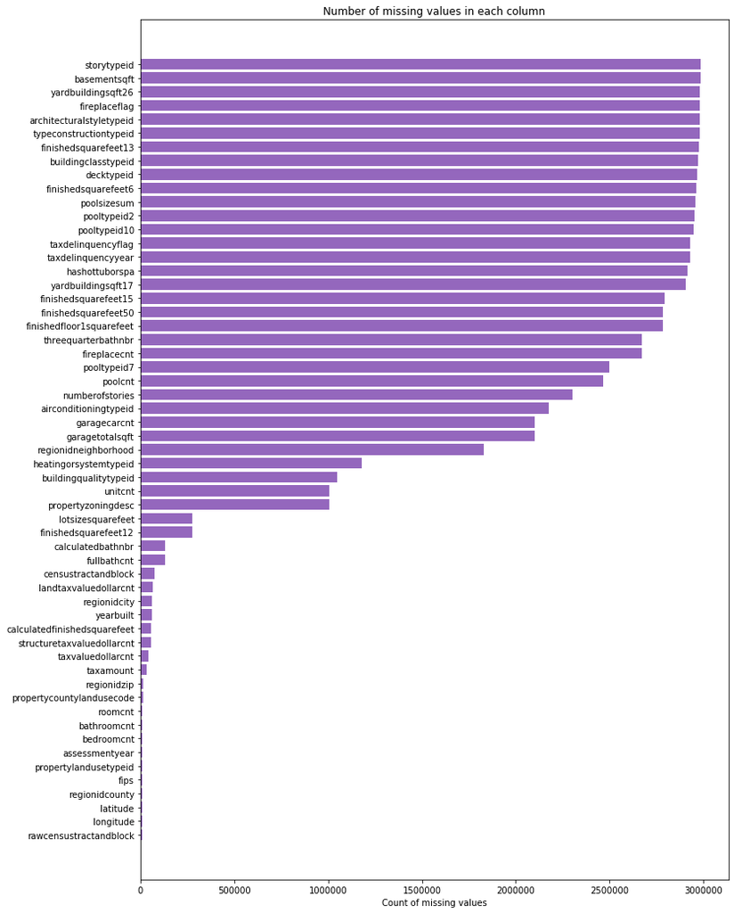

```python
ind = np.arange(missing_df.shape[0])
width = 0.9
fig, ax = plt.subplots(figsize=(12,18))
rects = ax.barh(ind, missing_df.missing_count.values, color=color[4])
ax.set_yticks(ind)
ax.set_yticklabels(missing_df.column_name.values, rotation='horizontal')
ax.set_xlabel("Count of missing values")
ax.set_title("Number of missing values in each column")
plt.show()
```

#### There are 34.5% of all attributes whose the number of missing values take 90% of total records.

```python
missing_df_90 = missing_df.loc[missing_df['missing_count']>prop2016.shape[0]*0.9]
percentage = missing_df_90.shape[0]/prop2016.shape[1]
percentage
```

```
0.3448275862068966
```

### Location Analysis

- Let us explore the latitude and longitude variables to begin with.
- From the data page, we are provided with a full list of real estate properties in three counties (Los Angeles, Orange and Ventura, California) data in 2016.

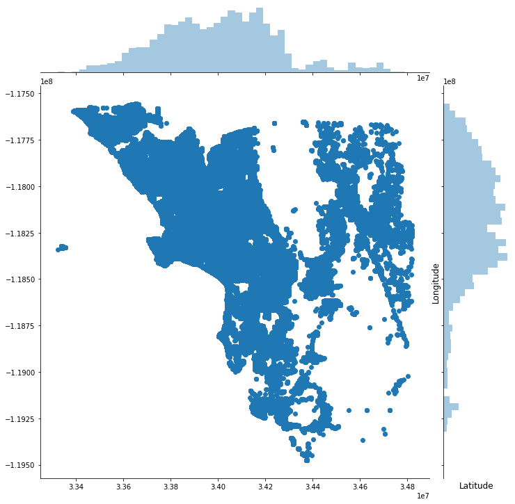

```python
plt.figure(figsize=(12,12))
sns.jointplot(x=prop2016.latitude.values, y=prop2016.longitude.values, size=10)
plt.ylabel('Longitude', fontsize=12)
plt.xlabel('Latitude', fontsize=12)
plt.show()
```

### Correlation Analysis

- Let us take the variables with high correlation values and do some analysis on them

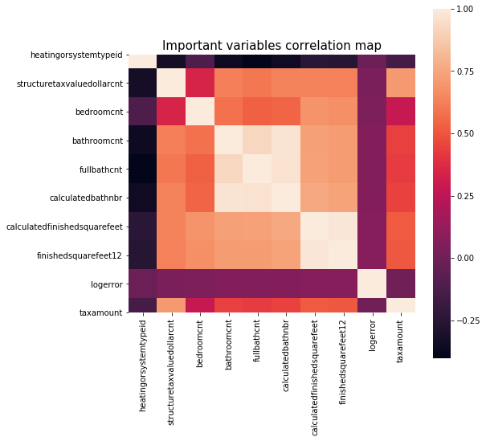

```python
df_train=train2016.merge(prop2016, how='left', on='parcelid')
df_train['transaction_month'] = df_train['transactiondate'].dt.month

# Let us just impute the missing values with mean values to compute correlation coefficients #
df_train = df_train.fillna(df_train.mean())

# Now let us look at the correlation coefficient of each of these variables #
x_cols = [col for col in df_train.columns if col not in ['logerror'] if df_train[col].dtype=='float64']

labels = []
values = []
for col in x_cols:
    labels.append(col)
    values.append(np.corrcoef(df_train[col].values, df_train.logerror.values)[0,1])
corr_df = pd.DataFrame({'col_labels':labels, 'corr_values':values})
corr_df = corr_df.sort_values(by='corr_values')

corr_df_sel = corr_df.loc[(corr_df['corr_values']>0.02) | (corr_df['corr_values'] < -0.01)]
cols_to_use = corr_df_sel.col_labels.tolist()
cols_to_use.append("logerror")
cols_to_use.append("taxamount")
df_train = df_train[cols_to_use]
corrmat = df_train.corr(method='spearman')
f, ax = plt.subplots(figsize=(8, 8))

# Draw the heatmap using seaborn
sns.heatmap(corrmat, vmax=1., square=True)
plt.title("Important variables correlation map", fontsize=15)
plt.show()
```

### logerror vs bathroom count

- Let's see how "logerror" changes with bathroom count

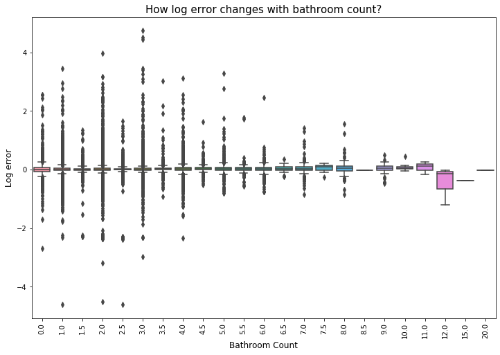

```python
plt.figure(figsize=(12,8))
sns.boxplot(x="bathroomcnt", y="logerror", data=df_train)
plt.ylabel('Log error', fontsize=12)
plt.xlabel('Bathroom Count', fontsize=12)
plt.xticks(rotation='vertical')
plt.title("How log error changes with bathroom count?", fontsize=15)
plt.show()
```

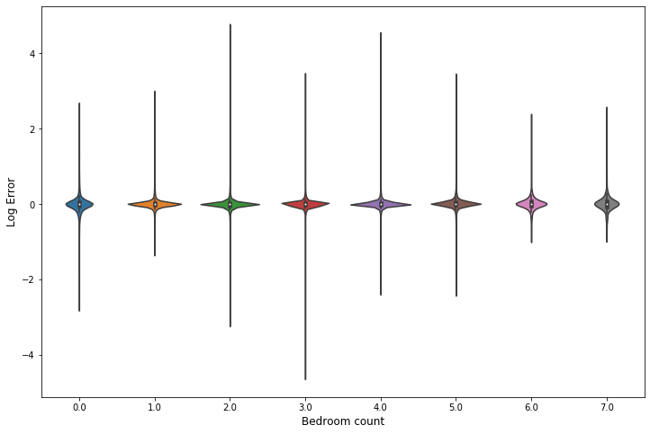

```python
df_train['bedroomcnt'].loc[df_train['bedroomcnt']>7] = 7
plt.figure(figsize=(12,8))
sns.violinplot(x='bedroomcnt', y='logerror', data=df_train)
plt.xlabel('Bedroom count', fontsize=12)
plt.ylabel('Log Error', fontsize=12)
plt.show()
```

### logerror vs taxamount

- Let's see how "logerror" changes with taxamount

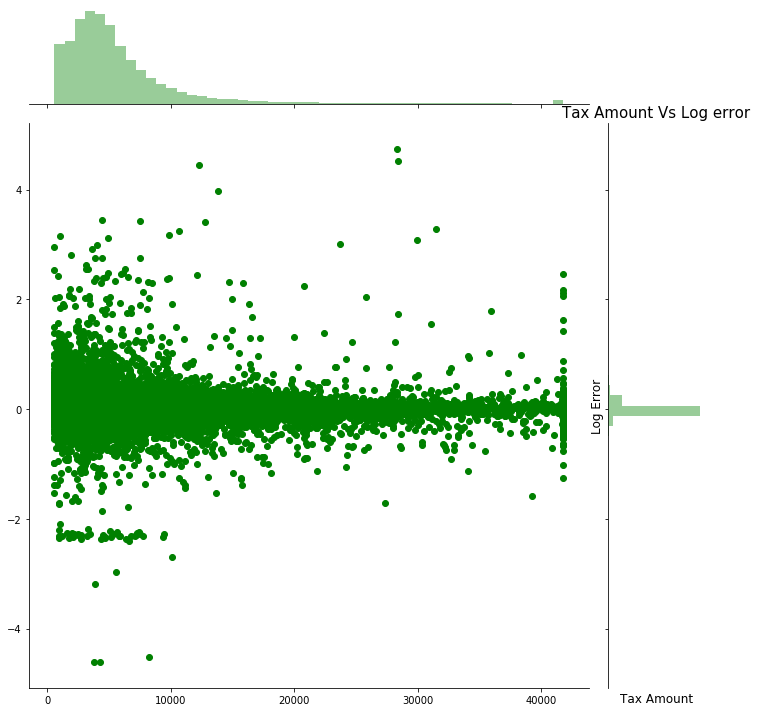

```python
col = "taxamount"
ulimit = np.percentile(df_train[col].values, 99.5)
llimit = np.percentile(df_train[col].values, 0.5)
df_train[col].loc[df_train[col]>ulimit] = ulimit
df_train[col].loc[df_train[col]<llimit] = llimit

plt.figure(figsize=(12,12))
sns.jointplot(x=df_train['taxamount'].values, y=df_train['logerror'].values, size=10, color='g')
plt.ylabel('Log Error', fontsize=12)
plt.xlabel('Tax Amount', fontsize=12)
plt.title("Tax Amount Vs Log error", fontsize=15)
plt.show()
```

## Step 2 Preprocessing

### Renaming attributes names to be meaningful

```python
df_train = train2016.merge(prop2016, how='left', on='parcelid')
df_train['transaction_month'] = df_train['transactiondate'].dt.month

df_train=df_train.rename(index=str,
                         columns={"pooltypeid7": "pool_with_spa_tub_no",
                                  "pooltypeid2": "pool_with_spa_tub_yes",
                                  "pooltypeid10": "just_hottub_or_spa",
                                  "hashottuborspa": "has_hottub_or_spa",
                                  "calculatedfinishedsquarefeet": "total_finished_living_area_sqft",
                                  "finishedsquarefeet12": "finished_living_area_sqft",
                                  "lotsizesquarefeet": "lot_area_sqft",
                                  "finishedsquarefeet50": "finished_living_area_entryfloor_sqft1",
                                  "finishedfloor1squarefeet": "finished_living_area_entryfloor_sqft2",
                                  "finishedsquarefeet6": "base_unfinished_and_finished_area_sqft",
                                  "finishedsquarefeet15": "total_area_sqft",
                                  "finishedsquarefeet13": "preimeter_living_area_sqft",
                                  "taxvaluedollarcnt":"total_parcel_tax",
                                  "landtaxvaluedollarcnt":"land_tax",
                                  "taxamount":"total_property_tax_2016",
                                  "structuretaxvaluedollarcnt":"structure_tax",
                                  "garagetotalsqft":"garage_sqft",
                                  "fireplacecnt":"fireplace_count",
                                  "buildingqualitytypeid ":"building_quality_id",
                                  "heatingorsystemtypeid":"heating_system_id",
                                  "airconditioningtypeid":"ac_id",
                                  "decktypeid": "deck_flag",
                                  "yardbuildingsqft17": "patio_sqft",
                                  "yardbuildingsqft26":"storage_sqft",
                                  "bathroomcnt": "total_bath",
                                  "fullbathcnt": "full_bath",
                                  "threequarterbathnbr": "half_bath",
                                  "storytypeid": "basement_flag",
                                  "poolsizesum": "pool_sqft"})
```

### Dealing Attributes with Missing Values

```python
#Pool_count，pool_with_spa_tub_no， pool_with_spa_tub_yes are binary variables, hence replace all NULL values with zero
df_train.loc[df_train.poolcnt.isnull(),'poolcnt']= 0
df_train.loc[df_train.pool_with_spa_tub_no.isnull(),'pool_with_spa_tub_no']=0
df_train.loc[df_train.pool_with_spa_tub_yes.isnull(),'pool_with_spa_tub_yes']=0

#When there is no pool, make poolsize as zero instead of Nan
df_train.loc[ df_train.poolcnt==0,'pool_sqft']=0

#basement_flag has values 7 & Null hence convert it to a binary variable with value of zero and 1
#When basement_flag is zero make basement_sqft also zero
df_train.loc[df_train.basement_flag.isnull(),'basementsqft']=0
df_train.loc[df_train.basement_flag.isnull(),'basement_flag']=0
df_train.loc[df_train.basement_flag==7,'basement_flag']=1

#There seems to be inconsistency between the fireplace_flag and fireplace count
df_train.loc[(df_train.fireplace_count.isnull()) & (df_train.fireplaceflag.isnull()),'fireplaceflag'] = False
df_train.loc[(df_train.fireplace_count.isnull()) & (df_train.fireplaceflag==False),'fireplace_count'] = 0
df_train.loc[df_train['fireplace_count']>0,'fireplaceflag']= True

#Dropping transaction date column as this doesn't have any corellation with target variable
df_train=df_train.drop('transactiondate',axis=1)

#Garage count and Garage size have same number of missing values.
#Let's assume this is because when there are properties with no garages then both variables are NA
df_train.loc[df_train.garage_sqft.isnull() & df_train.garagecarcnt.isnull(),['garagecarcnt','garage_sqft']]=0
df_train.loc[(df_train.garagecarcnt>0) & (df_train.garage_sqft==0),'garage_sqft']=np.nan

#total_bath & calculatedbathnbr are duplicates , and calculatedbathnbr has more nulls, hence drop it
df_train=df_train.drop('calculatedbathnbr',axis=1)

# full_bath is null & half_bath is null & total_bath=0 (missing values)
df_train.loc[(df_train.full_bath.isnull()) & (df_train.half_bath.isnull()) & (df_train.total_bath==0),'total_bath']=np.nan

# when full_bath=total_bath, half_bath=0
df_train.loc[(df_train.full_bath==df_train.total_bath) ,'half_bath']=0

#Assuming if these patio and shed variables has null values then there is no shed or patio in yard
df_train.loc[df_train.patio_sqft.isnull() ,'patio_sqft']=0
df_train.loc[df_train.storage_sqft.isnull() ,'storage_sqft']=0

#deck_flag has only 2 values 66 or null- convert it into binary flag
df_train.loc[df_train.deck_flag==66 ,'deck_flag']=1
df_train.loc[df_train.deck_flag.isnull() ,'deck_flag']=0

#if Tax deliquency flag is null, it is safe to assume there is no unpaid tax for the property
df_train.loc[df_train.taxdelinquencyflag.isnull(),'taxdelinquencyflag'] = "No"
df_train.loc[df_train.taxdelinquencyflag=='Y','taxdelinquencyflag'] = "Yes"
df_train.loc[df_train.taxdelinquencyflag=='No','taxdelinquencyyear'] = 0
```

### code fips code with respective county names

```
-  6037- LA
-  6059- Orange_County
-  6111- Ventura
```

```python
df_train.loc[df_train.fips==6037 ,'fips']="LA"
df_train.loc[df_train.fips==6059 ,'fips']="Orange_County"
df_train.loc[df_train.fips==6111 ,'fips']="Ventura"
print(df_train.fips.isnull().sum())
print(df_train.fips.value_counts())
```

```
0
LA               58574
Orange_County    24505
Ventura           7196
Name: fips, dtype: int64
```

### scaling down the latitude and longitide

- Knn imputation takes more time because of the hude numbers, moreover standardizing gives better results on most algorithms

```python
df_train['latitude']=df_train['latitude'].divide(100000)
df_train['longitude']=df_train['longitude'].divide(100000)
```

### drop some atrributes

```python
#"preimeter_living_area_sqft" and "total_finished_living_area_sqft" have the same values except that "preimeter_living_area_sqft" has more duplicates, Let's drop it
#"total_area_sqft" and "total_finished_living_area_sqft" have the same values except that "total_area_sqft" has more duplicates, Let's drop it
#"total_finished_living_area_sqft" and "finished_living_area_sqft" have the same values except that "finished_living_area_sqft" has more duplicates, Let's drop it
#"base_unfinished_and_finished_area_sqft" and "total_finished_living_area_sqft" have the same values except that "base_unfinished_and_finished_area_sqft" has more duplicates, Let's drop it
# From the analysis different counties follow different land use code, comparing different counties, zillow has created it's own "propertylandusetypeid" matching all the counties
# -to reduce number of levels, hence we can drop "propertycountylandusecode"
#Same applies to propertyzoningdesc as well
# Most zip id's either invalid or out of city, since enough information about location is given in latitude and longitude
#let's drop other location related fields：regionidcity, regionidzip, regionidneighborhood
#assessmentyear has a constant value for all the rows's, Let's drop it

df_train=df_train.drop('preimeter_living_area_sqft', axis=1)
df_train=df_train.drop('total_area_sqft', axis=1)
df_train=df_train.drop('finished_living_area_sqft', axis=1)
df_train=df_train.drop('base_unfinished_and_finished_area_sqft', axis=1)
df_train=df_train.drop(['propertycountylandusecode'], axis=1)
df_train=df_train.drop(['propertyzoningdesc'], axis=1)
df_train=df_train.drop(['regionidzip','regionidcity','regionidneighborhood'], axis=1)
df_train=df_train.drop(['assessmentyear'], axis=1)
```

### imputing unit count based on property land type

```python
#246 -Duplex (2 Units, Any Combination)
#247 -Triplex (3 Units, Any Combination)
#248 -Quadruplex (4 Units, Any Combination)
#260 -Residential General
#261 -Single Family Residential
#263 -Mobile Home
#264 -Townhouse
#266 -Condominium
#267 -Cooperative
#269 -Planned Unit Development
#275 -Residential Common Area
#31 - Commercial/Office/Residential Mixed Used
#47 -Store/Office (Mixed Use)
#265 -Cluster Home

df_train.loc[df_train.roomcnt==0 ,'roomcnt']=np.nan
df_train.loc[(df_train.propertylandusetypeid==31) & (df_train.unitcnt.isnull()),'unitcnt']=2
df_train.loc[(df_train.propertylandusetypeid==47) & (df_train.unitcnt.isnull()),'unitcnt']=2
df_train.loc[(df_train.propertylandusetypeid==246) & (df_train.unitcnt.isnull()),'unitcnt']=2
df_train.loc[(df_train.propertylandusetypeid==247) & (df_train.unitcnt.isnull()),'unitcnt']=3
df_train.loc[(df_train.propertylandusetypeid==248) & (df_train.unitcnt.isnull()),'unitcnt']=4
df_train.loc[(df_train.propertylandusetypeid==260) & (df_train.unitcnt.isnull()),'unitcnt']=1
df_train.loc[(df_train.propertylandusetypeid==261) & (df_train.unitcnt.isnull()),'unitcnt']=1
df_train.loc[(df_train.propertylandusetypeid==263) & (df_train.unitcnt.isnull()),'unitcnt']=1
df_train.loc[(df_train.propertylandusetypeid==264) & (df_train.unitcnt.isnull()),'unitcnt']=1
df_train.loc[(df_train.propertylandusetypeid==266) & (df_train.unitcnt.isnull()),'unitcnt']=1
df_train.loc[(df_train.propertylandusetypeid==267) & (df_train.unitcnt.isnull()),'unitcnt']=1
df_train.loc[(df_train.propertylandusetypeid==269) & (df_train.unitcnt.isnull()),'unitcnt']=1
df_train.loc[(df_train.propertylandusetypeid==275) & (df_train.unitcnt.isnull()),'unitcnt']=1
```

### convert yy to yyyy format

```python
df_train.loc[df_train.taxdelinquencyyear==99,'taxdelinquencyyear'] = 1999
df_train.loc[df_train.taxdelinquencyyear==6,'taxdelinquencyyear'] = 2006
df_train.loc[df_train.taxdelinquencyyear==7,'taxdelinquencyyear'] = 2007
df_train.loc[df_train.taxdelinquencyyear==8,'taxdelinquencyyear'] = 2008
df_train.loc[df_train.taxdelinquencyyear==9,'taxdelinquencyyear'] = 2009
df_train.loc[df_train.taxdelinquencyyear==10,'taxdelinquencyyear'] = 2010
df_train.loc[df_train.taxdelinquencyyear==11,'taxdelinquencyyear'] = 2011
df_train.loc[df_train.taxdelinquencyyear==12,'taxdelinquencyyear'] = 2012
df_train.loc[df_train.taxdelinquencyyear==13,'taxdelinquencyyear'] = 2013
df_train.loc[df_train.taxdelinquencyyear==14,'taxdelinquencyyear'] = 2014
df_train.loc[df_train.taxdelinquencyyear==15,'taxdelinquencyyear'] = 2015
df_train.loc[df_train.taxdelinquencyyear>0,'taxdelinquencyyear'] = 2016 - df_train['taxdelinquencyyear']
```

### do string split

```python
#awcensustractandblock has 3 fields concatened together, let's do string split
# both are float columns now
#rawcensustractandblock
s_rawcensustractandblock=df_train.rawcensustractandblock.apply(lambda x: str(x))

df_train['census_tractnumber']=s_rawcensustractandblock.str.slice(4,11)
df_train['block_number']=s_rawcensustractandblock.str.slice(start=11)
df_train['block_number']=df_train['block_number'].apply(lambda x: x[:4]+'.'+x[4:]+'0' )
df_train['block_number']=df_train['block_number'].apply(lambda x: int(round(float(x),0)) )
df_train['block_number']=df_train['block_number'].apply(lambda x: str(x).ljust(4,'0') )

#droping censustractandblock since this is just a duplicate of rawcensustractandblock
df_train=df_train.drop('censustractandblock', axis=1)

# drooping rawcensustractandblock, since it's already stored as substrings in different column names
df_train=df_train.drop('rawcensustractandblock', axis=1)
```

### drop some attributes again

- At this point most of the missing values are logically filled. Even now if some fields are missing more than 95% of values, then it doesn't make sense to try and impute them, because it will only add noise to the data

```python
missingvalues_prop = (df_train.isnull().sum()/len(df_train)).reset_index()
missingvalues_prop.columns = ['field','percentage']
missingvalues_prop = missingvalues_prop.sort_values(by = 'percentage', ascending = False)
#print(missingvalues_prop)
missingvaluescols = missingvalues_prop[missingvalues_prop['percentage'] > 0.95].field.tolist()

print(missingvaluescols)
```

```
['buildingclasstypeid', 'architecturalstyletypeid', 'typeconstructiontypeid', 'just_hottub_or_spa', 'has_hottub_or_spa']
```

```python
df_train = df_train.drop(['buildingclasstypeid', 'architecturalstyletypeid', 'typeconstructiontypeid'], axis=1)
```

### deal with missing values

```python
#unitcnt
df_train.loc[df_train.propertylandusetypeid==265,'unitcnt']=10
print(df_train.propertylandusetypeid.isnull().sum())

#pool_sqft
poolsizesum_mean = df_train.loc[df_train['poolcnt'] > 0, 'pool_sqft'].mean()
df_train.loc[df_train.pool_sqft.isnull(),'pool_sqft']=poolsizesum_mean
print(df_train.pool_sqft.isnull().sum())

#total_parcel_tax, structure_tax, land_tax, total_property_tax_2016
#recalculate total_parcel_tax =structure_tax + land_tax -> structure_tax=total_parcel_tax -land_tax
df_train.loc[(df_train.total_parcel_tax>0) & (df_train.land_tax>0),'structure_tax']=df_train['total_parcel_tax']-df_train['land_tax']
df_train.loc[df_train.structure_tax==0,'structure_tax']=np.nan
print(df_train.total_property_tax_2016.isnull().sum())
print(df_train.structure_tax.isnull().sum())
print(df_train.total_parcel_tax.isnull().sum())
print(df_train.land_tax.isnull().sum())

# regionidcounty is exact copy of fips code, dropping the dulicate column
df_train = df_train.drop(['regionidcounty'], axis=1)

#bedroomcnt #1421 zero bed room houses ??, observed it's missing all other room count also missing

df_train.loc[df_train.bedroomcnt==0,'bedroomcnt']= np.nan
print(df_train.bedroomcnt.isnull().sum())

# roomcnt
#=(full_bath+half_bath)+ bedroomcnt
# total_bath=fullbath+ 0.5(half_bath)
#caluculate full bath and half bath again from total bath as, it has few extra columns, (fixes 500 missing values in roomcnt )
df_train.loc[(df_train.full_bath.notnull())
             & (df_train.half_bath.notnull())
             & (df_train.bedroomcnt.notnull())
             & (df_train.roomcnt.isnull()),['roomcnt']]=df_train.full_bath + df_train.half_bath + df_train.bedroomcnt
# most bedroom count and roomcount null are in same place
# all column null count 1133 all columns are null
print(df_train.total_bath.isnull().sum())
print(df_train.full_bath.isnull().sum())
print(df_train.half_bath.isnull().sum())
print(df_train.bedroomcnt.isnull().sum())
print(df_train.roomcnt.isnull().sum())

#numberofstories	69705
df_train.loc[(df_train.propertylandusetypeid==246) & (df_train.numberofstories.notnull()),'numberofstories'].mode()
df_train.loc[(df_train.propertylandusetypeid==246) & (df_train.numberofstories.isnull()),'numberofstories']=2
df_train.loc[(df_train.propertylandusetypeid==247) & (df_train.numberofstories.notnull()),'numberofstories'].mode()
df_train.loc[(df_train.propertylandusetypeid==247) & (df_train.numberofstories.isnull()),'numberofstories']=2
df_train.loc[(df_train.propertylandusetypeid==248) & (df_train.numberofstories.notnull()),'numberofstories'].mode()
df_train.loc[(df_train.propertylandusetypeid==248) & (df_train.numberofstories.isnull()),'numberofstories']=2
df_train.loc[(df_train.propertylandusetypeid==260) & (df_train.numberofstories.notnull()),'numberofstories'].mode()
df_train.loc[(df_train.propertylandusetypeid==260) & (df_train.numberofstories.isnull()),'numberofstories']=2
df_train.loc[(df_train.propertylandusetypeid==261) & (df_train.numberofstories.notnull()),'numberofstories'].mode()
df_train.loc[(df_train.propertylandusetypeid==261) & (df_train.numberofstories.isnull()),'numberofstories']=1
df_train.loc[(df_train.propertylandusetypeid==263) & (df_train.numberofstories.notnull()),'numberofstories'].mode()
df_train.loc[(df_train.propertylandusetypeid==263) & (df_train.numberofstories.isnull()),'numberofstories']=1
df_train.loc[(df_train.propertylandusetypeid==266) & (df_train.numberofstories.notnull()),'numberofstories'].mode()
df_train.loc[(df_train.propertylandusetypeid==266) & (df_train.numberofstories.isnull()),'numberofstories']=1
df_train.loc[(df_train.propertylandusetypeid==269) & (df_train.numberofstories.notnull()),'numberofstories'].mode()
df_train.loc[(df_train.propertylandusetypeid==269) & (df_train.numberofstories.isnull()),'numberofstories']=2
prop2016.loc[(prop2016.propertylandusetypeid==275) & (prop2016.numberofstories.notnull()),'numberofstories'].mode()
df_train.loc[(df_train.propertylandusetypeid==275) & (df_train.numberofstories.isnull()),'numberofstories']=1
prop2016.loc[(prop2016.propertylandusetypeid==267) & (prop2016.numberofstories.notnull()),'numberofstories'].mode()
df_train.loc[(df_train.propertylandusetypeid==267) & (df_train.numberofstories.isnull()),'numberofstories']=1
df_train.loc[(df_train.propertylandusetypeid==264) & (df_train.numberofstories.isnull()),'numberofstories']=2
prop2016.loc[(prop2016.propertylandusetypeid==31) & (prop2016.numberofstories.notnull()),'numberofstories'].mode()
df_train.loc[(df_train.propertylandusetypeid==31) & (df_train.numberofstories.isnull()),'numberofstories']=2
print(df_train.numberofstories.isnull().sum())

#fireplace_count
df_train.loc[(df_train.fireplaceflag==1) & (df_train.fireplace_count.notnull()),'fireplace_count'].mode()
df_train.loc[(df_train.fireplaceflag==1) & (df_train.fireplace_count.isnull()),'fireplace_count']=1
```

```
0
0
6
380
1
1
1421
1165
1182
1182
1421
1416
0
```

### use knnclassifier to impute attributes which are related to location('latitude', 'longitude' )

```python
def fillna_knn( df, base, target):
    data_colnames = [ target ] + base
    #print("data_colnames",data_colnames)
    missing_values_boolflag = df[target].isnull() #true for missing rows, false for columns with values
    #print("miss",missing_values_boolflag.head())
    not_missing_boolflag = ~missing_values_boolflag
    #print("not miss",not_missing_boolflag.head())
    number_of_missing_val = missing_values_boolflag.sum()
    print("# of miss",number_of_missing_val)
    not_missing_rows = df.loc[ not_missing_boolflag, data_colnames ]
    #print(not_missing_rows.head())
    Y = not_missing_rows[target]
    X = not_missing_rows[base]
    X_train, X_test, Y_train, Y_test = train_test_split(X, Y, test_size=0.20, random_state=3192,stratify=Y)
    metrics       = ['euclidean']
    weights       = ['distance']
    numNeighbors  = [5,10,15,20,25]
    param_grid    = dict(metric=metrics,weights=weights,n_neighbors=numNeighbors)
    cv            = StratifiedKFold(n_splits=3,random_state=3192,shuffle=False)
    grid = GridSearchCV(neighbors.KNeighborsClassifier(n_jobs=-1),param_grid=param_grid,cv=cv,scoring='f1_weighted',refit=True,return_train_score=True,verbose=1,n_jobs=-1,pre_dispatch='n_jobs')
    grid.fit(X_train ,Y_train)
    #print("grid.cv_results_",grid.cv_results_)
    print("grid.best_estimator_",grid.best_estimator_)
    print("grid.best_params_",grid.best_params_)
    print("grid.scorer_",grid.scorer_)
    #print("grid.n_splits_",grid.n_splits_)
    y_true, y_pred = Y_test, grid.predict(X_test)

    Z = grid.predict(df.loc[missing_values_boolflag, base])
    #df.loc[ missing_values_boolflag, target ]  = Z
    return Z
```

```python
#impute buildingqualitytypeid with 'latitude', 'longitude'

print(df_train.buildingqualitytypeid.isnull().sum())
print(df_train.shape)
temp=df_train.copy()
temp['buildingqualitytypeid']=temp['buildingqualitytypeid'].fillna(-1)
temp=temp.groupby("buildingqualitytypeid").filter(lambda x: x.buildingqualitytypeid.size > 3)
temp['buildingqualitytypeid'] = temp['buildingqualitytypeid'].replace(-1,np.nan)
print(temp.buildingqualitytypeid.isnull().sum())
print(temp.shape)

missing_values=fillna_knn(temp,
                  base = [ 'latitude', 'longitude' ] ,
                  target = 'buildingqualitytypeid')

print("predicted output shape",missing_values.shape)
missing_values_boolflag = df_train['buildingqualitytypeid'].isnull()
df_train.loc[ missing_values_boolflag, 'buildingqualitytypeid' ]  = missing_values
print(df_train.buildingqualitytypeid.isnull().sum())
```

```
32911
(90275, 45)
32911
(90272, 45)
# of miss 32911
Fitting 3 folds for each of 5 candidates, totalling 15 fits
```

```
[Parallel(n_jobs=-1)]: Using backend LokyBackend with 4 concurrent workers.
[Parallel(n_jobs=-1)]: Done  15 out of  15 | elapsed:    7.9s finished
```

```
grid.best_estimator_ KNeighborsClassifier(algorithm='auto', leaf_size=30, metric='euclidean',
                     metric_params=None, n_jobs=-1, n_neighbors=10, p=2,
                     weights='distance')
grid.best_params_ {'metric': 'euclidean', 'n_neighbors': 10, 'weights': 'distance'}
grid.scorer_ make_scorer(f1_score, pos_label=None, average=weighted)
predicted output shape (32911,)
0
```

```python
#impute heating_system_id with 'latitude', 'longitude'

print(df_train.heating_system_id.isnull().sum())
print(df_train.shape)
temp=df_train.copy()
temp['heating_system_id']=temp['heating_system_id'].fillna(-1)
temp=temp.groupby("heating_system_id").filter(lambda x: x.heating_system_id.size > 3)
temp['heating_system_id'] = temp['heating_system_id'].replace(-1,np.nan)
print(temp.heating_system_id.isnull().sum())
print(temp.shape)

missing_values=fillna_knn(temp,
                  base = [ 'latitude', 'longitude' ] ,
                  target = 'heating_system_id')

print("predicted output shape",missing_values.shape)
missing_values_boolflag = df_train['heating_system_id'].isnull()
df_train.loc[ missing_values_boolflag, 'heating_system_id' ]  = missing_values

print(df_train.heating_system_id.isnull().sum())
```

```
34195
(90275, 45)
34195
(90269, 45)
# of miss 34195
Fitting 3 folds for each of 5 candidates, totalling 15 fits
```

```
[Parallel(n_jobs=-1)]: Using backend LokyBackend with 4 concurrent workers.
[Parallel(n_jobs=-1)]: Done  15 out of  15 | elapsed:    4.1s finished
```

```
grid.best_estimator_ KNeighborsClassifier(algorithm='auto', leaf_size=30, metric='euclidean',
                     metric_params=None, n_jobs=-1, n_neighbors=5, p=2,
                     weights='distance')
grid.best_params_ {'metric': 'euclidean', 'n_neighbors': 5, 'weights': 'distance'}
grid.scorer_ make_scorer(f1_score, pos_label=None, average=weighted)
predicted output shape (34195,)
0
```

```python
#impute ac_id with 'latitude', 'longitude'

print(df_train.ac_id.isnull().sum())
print(df_train.shape)
temp=df_train.copy()
temp['ac_id']=temp['ac_id'].fillna(-1)
temp=temp.groupby("ac_id").filter(lambda x: x.ac_id.size > 3)
temp['ac_id'] = temp['ac_id'].replace(-1,np.nan)
print(temp.ac_id.isnull().sum())
print(temp.shape)

missing_values=fillna_knn(temp,
                  base = [ 'latitude', 'longitude' ] ,
                  target = 'ac_id')

print("predicted output shape",missing_values.shape)
missing_values_boolflag = df_train['ac_id'].isnull()
df_train.loc[ missing_values_boolflag, 'ac_id' ]  = missing_values


print(df_train.ac_id.isnull().sum())
```

```
61494
(90275, 45)
61494
(90273, 45)
# of miss 61494
Fitting 3 folds for each of 5 candidates, totalling 15 fits
```

```
[Parallel(n_jobs=-1)]: Using backend LokyBackend with 4 concurrent workers.
[Parallel(n_jobs=-1)]: Done  15 out of  15 | elapsed:    2.3s finished
```

```
grid.best_estimator_ KNeighborsClassifier(algorithm='auto', leaf_size=30, metric='euclidean',
                     metric_params=None, n_jobs=-1, n_neighbors=25, p=2,
                     weights='distance')
grid.best_params_ {'metric': 'euclidean', 'n_neighbors': 25, 'weights': 'distance'}
grid.scorer_ make_scorer(f1_score, pos_label=None, average=weighted)
predicted output shape (61494,)
0
```

```python
#impute yearbuilt with 'latitude', 'longitude','buildingqualitytypeid','propertylandusetypeid'

print(df_train.yearbuilt.isnull().sum())
print(df_train.shape)
temp=df_train.copy()
temp['yearbuilt']=temp['yearbuilt'].fillna(-1)
temp=temp.groupby("yearbuilt").filter(lambda x: x.yearbuilt.size > 3)
temp['yearbuilt'] = temp['yearbuilt'].replace(-1,np.nan)
print(temp.yearbuilt.isnull().sum())
print(temp.shape)

missing_values=fillna_knn(temp,
                  base = [ 'latitude', 'longitude','buildingqualitytypeid','propertylandusetypeid' ] ,
                  target = 'yearbuilt')

print("predicted output shape",missing_values.shape)
missing_values_boolflag = df_train['yearbuilt'].isnull()
df_train.loc[ missing_values_boolflag, 'yearbuilt' ]  = missing_values
print(df_train.yearbuilt.isnull().sum())
```

```
756
(90275, 45)
756
(90261, 45)
# of miss 756
Fitting 3 folds for each of 5 candidates, totalling 15 fits
```

```
[Parallel(n_jobs=-1)]: Using backend LokyBackend with 4 concurrent workers.
[Parallel(n_jobs=-1)]: Done  15 out of  15 | elapsed:  1.0min finished
```

```
grid.best_estimator_ KNeighborsClassifier(algorithm='auto', leaf_size=30, metric='euclidean',
                     metric_params=None, n_jobs=-1, n_neighbors=5, p=2,
                     weights='distance')
grid.best_params_ {'metric': 'euclidean', 'n_neighbors': 5, 'weights': 'distance'}
grid.scorer_ make_scorer(f1_score, pos_label=None, average=weighted)
predicted output shape (756,)
0
```

### use knnregressor to impute attributes which are related to location('latitude', 'longitude' )

```python
from sklearn.model_selection import KFold

def fillna_knnr( df, base, target):
    data_colnames = [ target ] + base
    #print("data_colnames",data_colnames)
    missing_values_boolflag = df[target].isnull() #true for missing rows, false for columns with values
    #print("miss",missing_values_boolflag.head())
    not_missing_boolflag = ~missing_values_boolflag
    #print("not miss",not_missing_boolflag.head())
    number_of_missing_val = missing_values_boolflag.sum()
    print("# of miss",number_of_missing_val)
    not_missing_rows = df.loc[ not_missing_boolflag, data_colnames]
    #print(not_missing_rows.head())
    Y = not_missing_rows[target]
    X = not_missing_rows[base]
    X_train, X_test, Y_train, Y_test = train_test_split(X, Y, test_size=0.20, random_state=3192)
    metrics       = ['euclidean']
    weights       = ['distance']
    numNeighbors  = [5,10,15,20,25]
    param_grid    = dict(metric=metrics,weights=weights,n_neighbors=numNeighbors)
    cv            = KFold(n_splits=3,random_state=3192,shuffle=False)
    grid = GridSearchCV(neighbors.KNeighborsRegressor(n_jobs=-1),param_grid=param_grid,cv=cv,scoring='neg_mean_absolute_error',refit=True,return_train_score=True,verbose=1,n_jobs=-1,pre_dispatch='n_jobs')
    grid.fit(X_train ,Y_train)
    #print("grid.cv_results_",grid.cv_results_)
    print("grid.best_estimator_",grid.best_estimator_)
    print("grid.best_params_",grid.best_params_)
    print("grid.scorer_",grid.scorer_)
    #print("grid.n_splits_",grid.n_splits_)
    y_true, y_pred = Y_test, grid.predict(X_test)
    Z = grid.predict(df.loc[missing_values_boolflag, base])
    #df.loc[ missing_values_boolflag, target ]  = Z
    return Z
```

```python
#impute garage_sqft with 'latitude', 'longitude','garagecarcnt'

print(df_train.garage_sqft.isnull().sum())
print(df_train.shape)
temp=df_train.loc[df_train.garagecarcnt>0,df_train.columns].copy()

print(temp.garage_sqft.isnull().sum())
print(temp.shape)

missing_values=fillna_knnr(temp,
                  base = [ 'latitude', 'longitude','garagecarcnt'] ,
                  target = 'garage_sqft')

print("predicted output shape",missing_values.shape)
missing_values_boolflag = df_train['garage_sqft'].isnull()
df_train.loc[ missing_values_boolflag, 'garage_sqft' ] = missing_values
print(df_train.garage_sqft.isnull().sum())
```

```
8920
(90275, 45)
8920
(29647, 45)
# of miss 8920
Fitting 3 folds for each of 5 candidates, totalling 15 fits
```

```
[Parallel(n_jobs=-1)]: Using backend LokyBackend with 4 concurrent workers.
[Parallel(n_jobs=-1)]: Done  15 out of  15 | elapsed:    3.5s finished
```

```
grid.best_estimator_ KNeighborsRegressor(algorithm='auto', leaf_size=30, metric='euclidean',
                    metric_params=None, n_jobs=-1, n_neighbors=5, p=2,
                    weights='distance')
grid.best_params_ {'metric': 'euclidean', 'n_neighbors': 5, 'weights': 'distance'}
grid.scorer_ make_scorer(mean_absolute_error, greater_is_better=False)
predicted output shape (8920,)
0
```

```python
df_train = df_train.drop('parcelid', axis=1)
```

```python
#All the other columns with missing values seems to be  integer, will need regression to be imputed,
#time to get categorical variables hot encoded

#Identify numerical columns to produce a heatmap
catcols = ['ac_id','buildingqualitytypeid','deck_flag','fips', 'heating_system_id','has_hottub_or_spa',
          'just_hottub_or_spa', 'pool_with_spa_tub_yes','pool_with_spa_tub_no','propertylandusetypeid','basement_flag'
          ,'fireplaceflag','taxdelinquencyflag']
numcols = [x for x in df_train.columns if x not in catcols]

#total_finished_living_area_sqft

print(df_train.total_finished_living_area_sqft.isnull().sum())
print(df_train.shape)
temp=df_train.copy()
print(temp.total_finished_living_area_sqft.isnull().sum())
print(temp.shape)
missing_values=fillna_knnr(temp,
                  base = [ 'latitude', 'longitude','basementsqft','numberofstories','poolcnt','garagecarcnt','garage_sqft','propertylandusetypeid'] ,
                  target = 'total_finished_living_area_sqft')

print("predicted output shape",missing_values.shape)
missing_values_boolflag = df_train['total_finished_living_area_sqft'].isnull()
df_train.loc[ missing_values_boolflag, 'total_finished_living_area_sqft' ] = missing_values
print(df_train.total_finished_living_area_sqft.isnull().sum())
```

```
661
(90275, 44)
661
(90275, 44)
# of miss 661
Fitting 3 folds for each of 5 candidates, totalling 15 fits
```

```
[Parallel(n_jobs=-1)]: Using backend LokyBackend with 4 concurrent workers.
[Parallel(n_jobs=-1)]: Done  15 out of  15 | elapsed:  2.1min finished
```

```
grid.best_estimator_ KNeighborsRegressor(algorithm='auto', leaf_size=30, metric='euclidean',
                    metric_params=None, n_jobs=-1, n_neighbors=15, p=2,
                    weights='distance')
grid.best_params_ {'metric': 'euclidean', 'n_neighbors': 15, 'weights': 'distance'}
grid.scorer_ make_scorer(mean_absolute_error, greater_is_better=False)
predicted output shape (661,)
0
```

```python
#total_bath	1165
#full_bath	1182
#half_bath	1182
#roomcnt	1416
#bedroomcnt	1421

#total_finished_living_area_sqft

print(df_train.total_bath.isnull().sum())
print(df_train.shape)
temp=df_train.copy()
print(temp.total_bath.isnull().sum())
print(temp.shape)
missing_values=fillna_knnr(temp,
                  base = ['propertylandusetypeid','total_finished_living_area_sqft' ] ,
                  target = 'total_bath')

print("predicted output shape",missing_values.shape)
missing_values_boolflag = df_train['total_bath'].isnull()
df_train.loc[ missing_values_boolflag, 'total_bath' ] = missing_values
print(df_train.total_bath.isnull().sum())
```

```
1165
(90275, 44)
1165
(90275, 44)
# of miss 1165
Fitting 3 folds for each of 5 candidates, totalling 15 fits
```

```
[Parallel(n_jobs=-1)]: Using backend LokyBackend with 4 concurrent workers.
[Parallel(n_jobs=-1)]: Done  15 out of  15 | elapsed:    8.0s finished
```

```
grid.best_estimator_ KNeighborsRegressor(algorithm='auto', leaf_size=30, metric='euclidean',
                    metric_params=None, n_jobs=-1, n_neighbors=25, p=2,
                    weights='distance')
grid.best_params_ {'metric': 'euclidean', 'n_neighbors': 25, 'weights': 'distance'}
grid.scorer_ make_scorer(mean_absolute_error, greater_is_better=False)
predicted output shape (1165,)
0
```

```python
#drop half_bath and full bath, as there are only redundant values of total_bath
df_train = df_train.drop(['full_bath','half_bath'], axis=1)
```

```python
#bedroomcnt	1421

print(df_train.bedroomcnt.isnull().sum())
print(df_train.shape)
temp=df_train.copy()
print(temp.bedroomcnt.isnull().sum())
print(temp.shape)
missing_values=fillna_knnr(temp,
                  base = ['propertylandusetypeid','total_finished_living_area_sqft','total_bath' ] ,
                  target = 'bedroomcnt')

print("predicted output shape",missing_values.shape)
missing_values_boolflag = df_train['bedroomcnt'].isnull()
df_train.loc[ missing_values_boolflag, 'bedroomcnt' ] = missing_values
print(df_train.bedroomcnt.isnull().sum())

df_train['total_bath']=df_train.total_bath.round(1)
df_train['bedroomcnt']=df_train.bedroomcnt.round(1)

#recalculate roomcnt	1416 as we have used imputation for total_bath and bedroomcnt
df_train.loc[(df_train.roomcnt.isnull()),['roomcnt']]=df_train.total_bath + df_train.bedroomcnt

print(df_train.shape)
df_train =df_train.loc[(df_train.total_parcel_tax.notnull()) & (df_train.land_tax.notnull()),df_train.columns]

print(df_train.shape)
```

```
1421
(90275, 42)
1421
(90275, 42)
# of miss 1421
Fitting 3 folds for each of 5 candidates, totalling 15 fits
```

```
[Parallel(n_jobs=-1)]: Using backend LokyBackend with 4 concurrent workers.
[Parallel(n_jobs=-1)]: Done  15 out of  15 | elapsed:   11.0s finished
```

```
grid.best_estimator_ KNeighborsRegressor(algorithm='auto', leaf_size=30, metric='euclidean',
                    metric_params=None, n_jobs=-1, n_neighbors=25, p=2,
                    weights='distance')
grid.best_params_ {'metric': 'euclidean', 'n_neighbors': 25, 'weights': 'distance'}
grid.scorer_ make_scorer(mean_absolute_error, greater_is_better=False)
predicted output shape (1421,)
0
(90275, 42)
(90274, 42)
```

```python
#lot_area_sqft
print(df_train.lot_area_sqft.isnull().sum())
print(df_train.shape)
temp=df_train.copy()
print(temp.lot_area_sqft.isnull().sum())
print(temp.shape)
missing_values=fillna_knnr(temp,
                  base = ['latitude','longitude','propertylandusetypeid','total_finished_living_area_sqft','roomcnt','numberofstories' ] ,
                  target = 'lot_area_sqft')

print("predicted output shape",missing_values.shape)
missing_values_boolflag = df_train['lot_area_sqft'].isnull()
df_train.loc[ missing_values_boolflag, 'lot_area_sqft' ] = missing_values.round(2)
print(df_train.lot_area_sqft.isnull().sum())
```

```
10150
(90274, 42)
10150
(90274, 42)
# of miss 10150
Fitting 3 folds for each of 5 candidates, totalling 15 fits
```

```
[Parallel(n_jobs=-1)]: Using backend LokyBackend with 4 concurrent workers.
[Parallel(n_jobs=-1)]: Done  15 out of  15 | elapsed:   18.0s finished
```

```
grid.best_estimator_ KNeighborsRegressor(algorithm='auto', leaf_size=30, metric='euclidean',
                    metric_params=None, n_jobs=-1, n_neighbors=15, p=2,
                    weights='distance')
grid.best_params_ {'metric': 'euclidean', 'n_neighbors': 15, 'weights': 'distance'}
grid.scorer_ make_scorer(mean_absolute_error, greater_is_better=False)
predicted output shape (10150,)
0
```

```python
# predict structure_tax and recalculate  total_parcel_tax = land_tax + structure_tax

print(df_train.structure_tax.isnull().sum())
print(df_train.shape)
temp=df_train.copy()
print(temp.structure_tax.isnull().sum())
print(temp.shape)
missing_values=fillna_knnr(temp,
                  base = ['latitude','longitude','lot_area_sqft','propertylandusetypeid','total_finished_living_area_sqft','roomcnt','numberofstories' ] ,
                  target = 'structure_tax')

print("predicted output shape",missing_values.shape)
missing_values_boolflag = df_train['structure_tax'].isnull()
df_train.loc[ missing_values_boolflag, 'structure_tax' ] = missing_values.round(2)
print(df_train.structure_tax.isnull().sum())
```

```
379
(90274, 42)
379
(90274, 42)
# of miss 379
Fitting 3 folds for each of 5 candidates, totalling 15 fits
```

```
[Parallel(n_jobs=-1)]: Using backend LokyBackend with 4 concurrent workers.
[Parallel(n_jobs=-1)]: Done  15 out of  15 | elapsed:   11.3s finished
```

```
grid.best_estimator_ KNeighborsRegressor(algorithm='auto', leaf_size=30, metric='euclidean',
                    metric_params=None, n_jobs=-1, n_neighbors=25, p=2,
                    weights='distance')
grid.best_params_ {'metric': 'euclidean', 'n_neighbors': 25, 'weights': 'distance'}
grid.scorer_ make_scorer(mean_absolute_error, greater_is_better=False)
predicted output shape (379,)
0
```

```python
#total_property_tax_2016
#total_parcel_tax = land_tax + structure_tax

df_train['total_parcel_tax']=df_train['structure_tax']+df_train['land_tax']

print(df_train.total_property_tax_2016.isnull().sum())
print(df_train.shape)
temp=df_train.copy()
print(temp.total_property_tax_2016.isnull().sum())
print(temp.shape)
missing_values=fillna_knnr(temp,
                  base = ['latitude','longitude','lot_area_sqft','propertylandusetypeid','total_finished_living_area_sqft','roomcnt','numberofstories' ] ,
                  target = 'total_property_tax_2016')

print("predicted output shape",missing_values.shape)
missing_values_boolflag = df_train['total_property_tax_2016'].isnull()
df_train.loc[ missing_values_boolflag, 'total_property_tax_2016' ] = missing_values.round(2)
print(df_train.total_property_tax_2016.isnull().sum())
```

```
6
(90274, 42)
6
(90274, 42)
# of miss 6
Fitting 3 folds for each of 5 candidates, totalling 15 fits
```

```
[Parallel(n_jobs=-1)]: Using backend LokyBackend with 4 concurrent workers.
[Parallel(n_jobs=-1)]: Done  15 out of  15 | elapsed:   13.4s finished
```

```
grid.best_estimator_ KNeighborsRegressor(algorithm='auto', leaf_size=30, metric='euclidean',
                    metric_params=None, n_jobs=-1, n_neighbors=25, p=2,
                    weights='distance')
grid.best_params_ {'metric': 'euclidean', 'n_neighbors': 25, 'weights': 'distance'}
grid.scorer_ make_scorer(mean_absolute_error, greater_is_better=False)
predicted output shape (6,)
0
```

```python
#age of the property
df_train['age'] = 2016 - df_train['yearbuilt']
df_train=df_train.drop(['yearbuilt'],axis=1)
```

### clear the data after imputing

```python
#check missing values
missing_df = df_train.isnull().sum(axis=0).reset_index()
missing_df.columns = ['column_name', 'missing_count']
missing_df = missing_df.loc[missing_df['missing_count']>0]
missing_df = missing_df.sort_values(by='missing_count')
print(missing_df)
print(missing_df.shape)

#both the columns above miss 92% of the data, there is no related varibale to impute it, hence dropping them at this point
df_train = df_train.drop(['finished_living_area_entryfloor_sqft2','finished_living_area_entryfloor_sqft1'], axis=1)

#Identify numerical columns to produce a heatmap
catcols = ['ac_id','buildingqualitytypeid','deck_flag','fips','pool_with_spa_tub_no','pool_with_spa_tub_yes','has_hottub_or_spa',
           'just_hottub_or_spa','heating_system_id','propertylandusetypeid','basement_flag','fireplaceflag','taxdelinquencyflag']
numcols = [x for x in df_train.columns if x not in catcols]

# 2 variables are in object datatype, coverting into numeric
df_train[['census_tractnumber','block_number']] = df_train[['census_tractnumber','block_number']].apply(pd.to_numeric)

# dropping categorical columns as xgboost feature selection cannot handle it
train_x = df_train.drop(catcols+['logerror'], axis=1)
train_y=df_train['logerror']
train_x = train_x.astype(float)
train_y = train_y.astype(float)

pd.options.display.max_rows = 65

#dtype_df
dtype_df = train_x.dtypes.reset_index()
dtype_df.columns = ["Count", "Column Type"]

#dummieslist
df_train.loc[df_train.has_hottub_or_spa==True,'has_hottub_or_spa']="Yes"
df_train.loc[df_train.has_hottub_or_spa==0,'has_hottub_or_spa']="No"

df_train.loc[df_train.just_hottub_or_spa==0,'just_hottub_or_spa']="No"
df_train.loc[df_train.just_hottub_or_spa==1,'just_hottub_or_spa']="Yes"

df_train.loc[df_train.deck_flag==0,'deck_flag']="No"
df_train.loc[df_train.deck_flag==1,'deck_flag']="Yes"

df_train.loc[df_train.basement_flag==0,'basement_flag']="No"
df_train.loc[df_train.basement_flag==1,'basement_flag']="Yes"

df_train.loc[df_train.fireplaceflag==False,'fireplaceflag']="No"
df_train.loc[df_train.fireplaceflag==True,'fireplaceflag']="Yes"

#ac_id,heating_system_id,propertylandusetypeid
dummieslist=['has_hottub_or_spa','just_hottub_or_spa',
             'deck_flag','fips','basement_flag','fireplaceflag','taxdelinquencyflag']

df_train[dummieslist] = df_train[dummieslist].astype(object)
dummies = pd.get_dummies(df_train[dummieslist], prefix= dummieslist)
dummies.shape

#dummies2=['pool_with_spa_tub_no','pool_with_spa_tub_yes']
#df_train[dummies2] = df_train[dummies2].astype(int)
```

```
                              column_name  missing_count
7   finished_living_area_entryfloor_sqft2          83419
9   finished_living_area_entryfloor_sqft1          83419
14                      has_hottub_or_spa          87909
21                     just_hottub_or_spa          89113
(4, 2)
```

```
(90274, 13)
```

```python
df_train.shape
```

```
(90274, 40)
```

## Step 3 Feature Selection & Dimensionality Reduction

The below mentioned techniques are used to make feature selection and dimensionality reduction:

- XgBoost feature importance (Information Gain & Gini Index)
- TreeRegressor feature importance (Information Gain & Gini Index)
- Recursive feature elimination (RFE)
- PCA (Principal Component Analysis)

### split dataset into training and test

```python
#regulate the data types in fields(---> int, float or bool)to build X

#numerical columns
numcols2=['basementsqft','total_bath','bedroomcnt','total_finished_living_area_sqft','fireplace_count','garagecarcnt',
 'garage_sqft','latitude','longitude','lot_area_sqft','poolcnt','pool_sqft','roomcnt','unitcnt','patio_sqft','storage_sqft',
 'numberofstories','structure_tax','total_parcel_tax','land_tax','total_property_tax_2016','taxdelinquencyyear','transaction_month',
 'census_tractnumber','block_number','age']

#buildingqualitytypeid ->has order
le = LabelEncoder()
df_train['buildingqualitytypeid']=le.fit_transform(df_train.buildingqualitytypeid)

dummies2=['pool_with_spa_tub_no','pool_with_spa_tub_yes']
df_train[dummies2] = df_train[dummies2].astype(int)

X=pd.concat([dummies,df_train[dummies2],df_train[numcols2],df_train[['buildingqualitytypeid','ac_id','heating_system_id','propertylandusetypeid']]],axis=1)
X.shape

#build Y
Y=df_train['logerror']

#split the dataset into train and test
X_train, X_test, Y_train, Y_test = train_test_split(X, Y, test_size=0.10, random_state=3192)
```